# Using python for statistical analysis

There's an interactive shell for python called IPython that makes exploratory data analysis easier. And since you're using a programming language, it's reproducible. Plus you can use the IPython Notebook to present your final work.

Also, the [Python Data Analysis Library](http://pandas.pydata.org/) or pandas is really powerful. I believe the acronym *pandas* comes from a combination of *panel data* & *python data analysis.*

Don't confuse *pandas* with the equally great [PANDA: A Newsroom Data Appliance.](http://panda.readthedocs.org/en/1.1.1/)

Finaly the creator of pandas wrote a [whole book](http://shop.oreilly.com/product/0636920023784.do) on how to use pandas and IPython to do data analysis.

Now for the main event.

The first block of python code sets things up. We fire up the charting library matplotlib in inline mode so that our charts are displayed here inside the notebook.

Then we import the "ordinary least squares" statistical regression technique implemented in python by pandas.

Then we import the whole pandas libary for us to use under the abbreviated name "pd."

After that the code is fairly straight forward.

```python
%matplotlib inline
from pandas.stats.api import ols
import pandas as pd
```

```python
df = pd.read_csv('testscores.csv')
df.columns
```

```
Index([u'district', u'school', u'students', u'pcttest', u'pctpoor', u'score'], dtype='object')
```

```python
df['score'].describe()
```

```
count    115.000000
mean     182.867826
std       30.024617
min      100.000000
25%      165.900000
50%      191.300000
75%      204.250000
max      229.600000
Name: score, dtype: float64
```

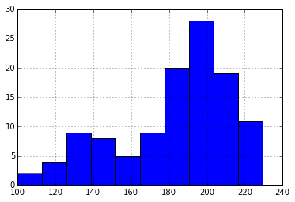

```python
df['score'].hist()
```

```python
df['pctpoor'].describe()
```

```
count    112.000000
mean      45.952571
std       30.699618
min        5.687000
25%       21.648000
50%       34.834000
75%       76.856250
max      100.000000
Name: pctpoor, dtype: float64
```

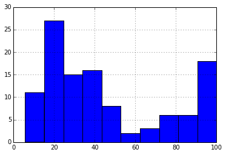

```python
df['pctpoor'].hist()
```

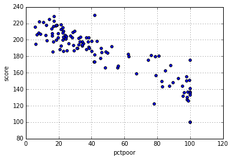

```python
df.plot(kind='scatter', x='pctpoor', y='score')
```

```python
df.corr()
```

|  | students | pcttest | pctpoor | score |
| --- | --- | --- | --- | --- |
| students | 1.000000 | 0.174064 | -0.433485 | 0.461339 |
| pcttest | 0.174064 | 1.000000 | -0.374446 | 0.437552 |
| pctpoor | -0.433485 | -0.374446 | 1.000000 | -0.896007 |
| score | 0.461339 | 0.437552 | -0.896007 | 1.000000 |

```python
res = ols(y=df['score'], x=df['pctpoor'])
res
```

```
-------------------------Summary of Regression Analysis-------------------------

Formula: Y ~ <x> + <intercept>

Number of Observations:         112
Number of Degrees of Freedom:   2

R-squared:         0.8028
Adj R-squared:     0.8010

Rmse:             12.8822

F-stat (1, 110):   447.8889, p-value:     0.0000

Degrees of Freedom: model 1, resid 110

-----------------------Summary of Estimated Coefficients------------------------
      Variable       Coef    Std Err     t-stat    p-value    CI 2.5%   CI 97.5%
--------------------------------------------------------------------------------
             x    -0.8429     0.0398     -21.16     0.0000    -0.9210    -0.7648
     intercept   223.1391     2.1980     101.52     0.0000   218.8309   227.4473
---------------------------------End of Summary---------------------------------
```

# Interested in learning how seasoned reporters use statistics to get good stories?

Go to an IRE/NICAR stats bootcamp like the one coming soon to Washington, DC